# Sine Regression

Owen Ward

October 27, 2017

First off we want to read in the data from the web address (it’s updated daily).

```r
library("RCurl")
```

```r
library("reshape2")
library("ggplot2")
library("readr")
library("dplyr")
#Baltimore Crime Data 2:47
# url <-"https://data.baltimorecity.gov/api/views/xviu-ezkt/rows.csv?accessType=DOWNLOAD"
# Data <- read_csv(url)
setwd("C:/Users/owenw/Dropbox/PhD/Data Science Course/Crime")
Data <- read_csv("911_Calls_for_Service.csv")
```

To plot the data geographically on top of a map of Baltimore, need to extract the latitude and longitude so they can be plotted as x and y coordinates.

```r
#location
locs <- strsplit(gsub("[()]","",Data$location),",")
missing <- sapply(locs, function(x) length(x) != 2)
locs <- matrix(unlist(locs[!missing]),
               ncol = 2, byrow = TRUE)

Data$lon <- Data$lat <- NA
Data$lon[!missing] <- as.numeric(locs[,2])
Data$lat[!missing] <- as.numeric(locs[,1])
```

Then these can be plotted.

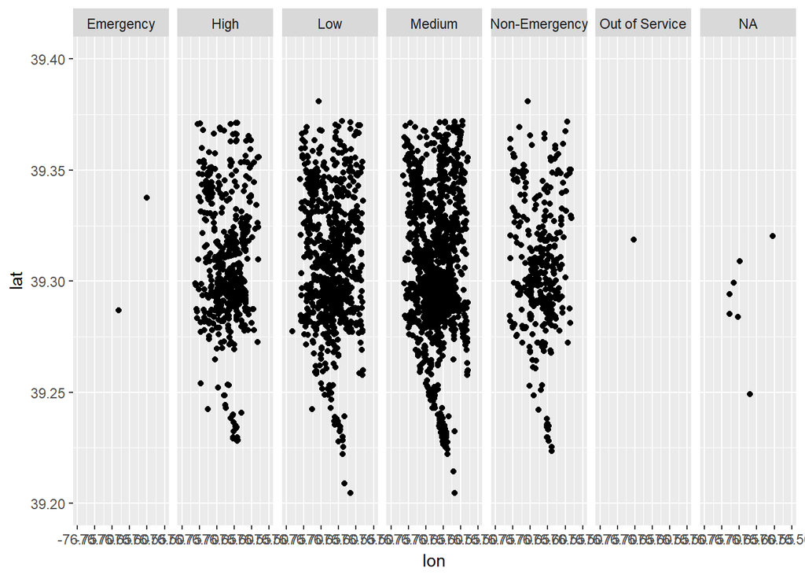

```r
library(ggplot2)
ggplot(Data[1:5000,]) +
  aes(lon, lat) +
  geom_point() +
  xlim(-76.75, -76.5) +
  ylim(39.2, 39.4) +
  facet_grid(~priority)
```

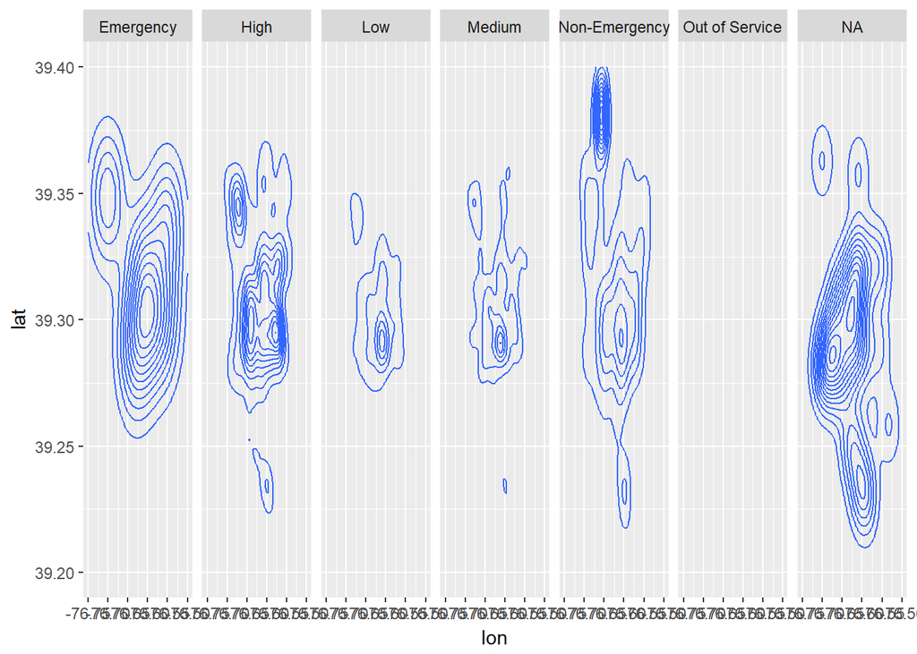

```r
ggplot(Data[1:10000,]) +
  aes(lon, lat) +
  geom_density_2d() +
  xlim(-76.75, -76.5) +
  ylim(39.2, 39.4) +
  facet_grid(~priority)
```

These stratify by priority. Could stratify by location too (and then each plot will be over a different region). They can easily be plotted on a map of Baltimore.

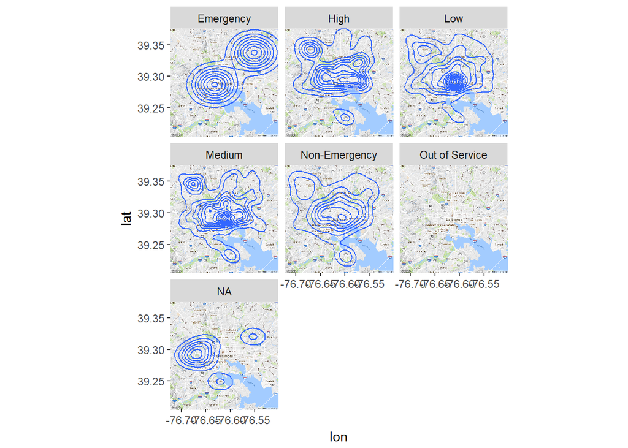

```r
library(ggmap)
ggmap(get_map("Baltimore, Maryland", zoom = 12)) +
  geom_density_2d(aes(lon, lat), data = Data[1:5000,]) +
  facet_wrap(~priority)
```

It makes sense to think that there will be some sort of trends in the data. You would expect crime to be very low early in the morning and much higher in the evening, or crimes will be lower in the winter than summer. To capture this we will fit a sine regression. Initially we will fit this to the number of crimes each day.

```r
Data$date <- as.Date(Data$callDateTime, format = "%m/%d/%Y %H:%M:%S")

crime_count <- dplyr::count(Data, date)

model1 <- lm(n ~ date, crime_count)
ssp <- spectrum(crime_count$n)
```

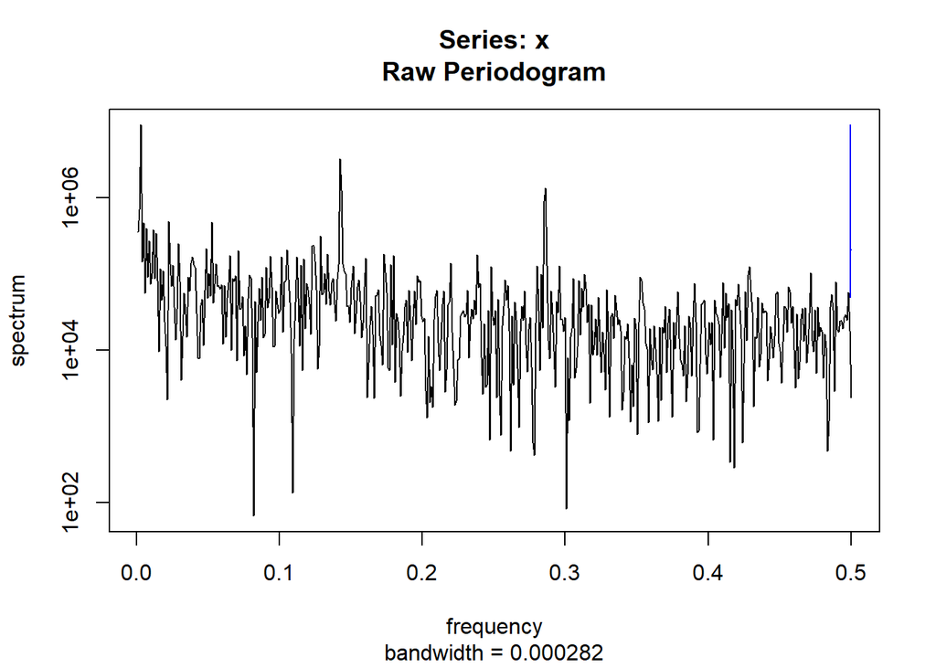

```r
period <- 1/ssp$freq[ssp$spec == max(ssp$spec)]
period
```

```
## [1] 341.3333
```

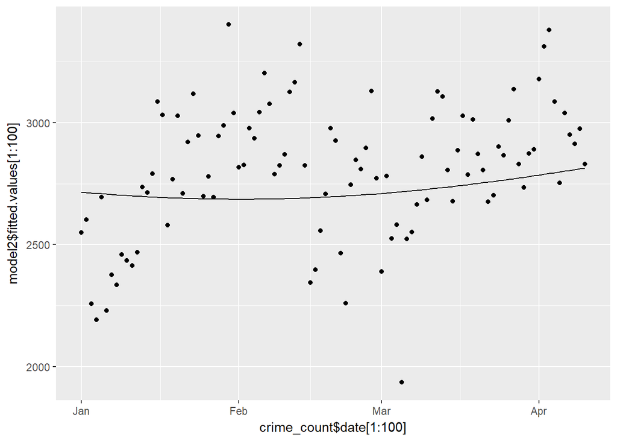

```r
model2 <- lm(n ~ cos(2 * pi * as.numeric(date)/period) +
               sin(2 * pi * as.numeric(date)/period), crime_count)
qplot(crime_count$date[1:100], model2$fitted.values[1:100],
      geom = "line") + geom_point(aes(date,n),data = crime_count[1:100,])
```

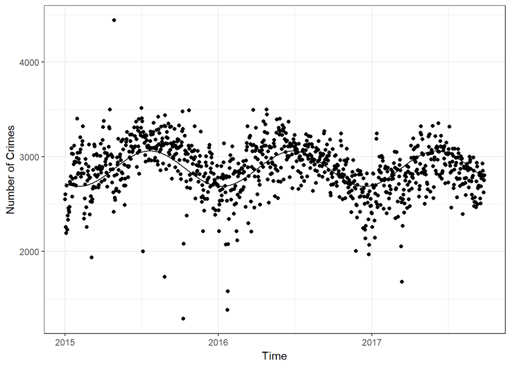

```r
qplot(crime_count$date[1:1000], model2$fitted.values[1:1000],
      geom = "line") +
  geom_point(aes(date,n),data = crime_count[1:1000,])+
  labs(x="Time",y="Number of Crimes")+
  theme_bw()
```

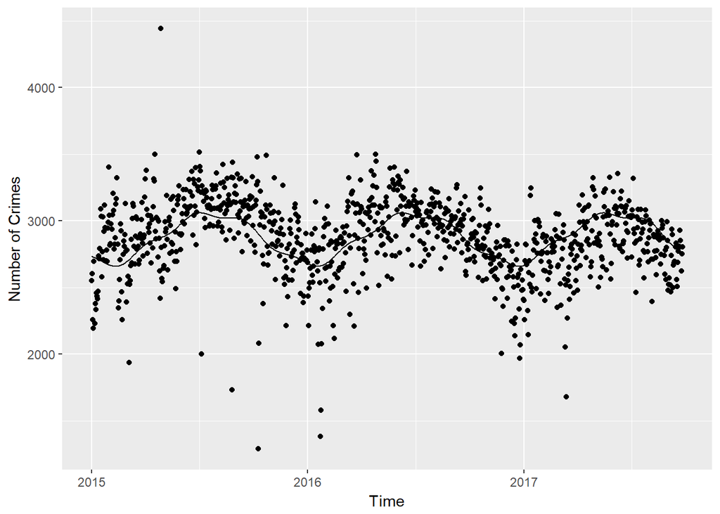

```r
model3 <- lm(n ~ cos(as.numeric(date) * 2 * pi / period) +
               sin(as.numeric(date) * 2 * pi / period) +
               cos(as.numeric(date) * 4 * pi / period) +
               sin(as.numeric(date) * 4 * pi / period) +
               cos(as.numeric(date) * 8 * pi / period) +
               sin(as.numeric(date) * 8 * pi / period),
             crime_count)

qplot(crime_count$date[1:1000], model3$fitted.values[1:1000], geom = "line") +
  geom_point(aes(date,n),data = crime_count[1:1000,]) +
  labs(x="Time",y="Number of Crimes")
```

A better model might be to fit across hour of the week, if you think there is an effect related to school or something.

```r
crime <- Data
crime$Time <- as.POSIXct(x = crime$callDateTime,tz= "EST",
                         format =  "%m/%d/%Y %I:%M:%S %p")
crime$Hour <- as.numeric(format(crime$Time, "%H"))
crime$Minute <- as.numeric(format(crime$Time, "%M"))
crime$hour_min <- crime$Hour + crime$Minute/60
crime$weekdays <- factor(weekdays(crime$Time),
                         levels = c("Monday", "Tuesday", "Wednesday",
                                    "Thursday", "Friday", "Saturday", "Sunday"))
crime$week_num <- as.numeric(crime$weekdays)
crime$t = crime$hour_min + 24 * (crime$week_num - 1)

period <- 24
```

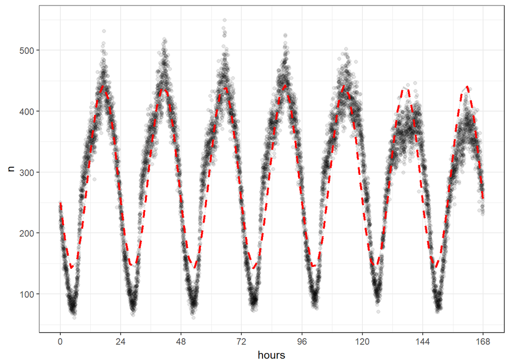

```r
ggplot(count(crime, t)) +
  aes(t, n) +
  geom_point(alpha = .1) +
  theme_bw() +
  geom_smooth(formula = y ~ sin(2*pi*x/period) + cos(2*pi*x/period), color = "red",
              method = "lm", linetype = 2, alpha = .5) +
  scale_x_continuous(breaks = seq(0, period * 7, period)) +
  labs(x = "hours", n = "number of reports")
```

```r
model1 <- lm(n ~ sin(2*pi*t/period) + cos(2*pi*t/period), count(crime, t))

shift <- unname(model1$coefficients[1])
ampl <- unname(sqrt(model1$coefficients[2]^2 + model1$coefficients[3]^2))
phase <- unname(atan(model1$coefficients[3]/model1$coefficients[2]))


phase * 24 / (2 * pi) #offset of sine curve (in units t)
```

```
## [1] 1.077731
```

```r
shift #average y value (increase above 0)
```

```
## [1] 291.8776
```

```r
ampl #increase above average y value (factor time 1)
```

```
## [1] 150.9827
```

```r
period
```

```
## [1] 24
```

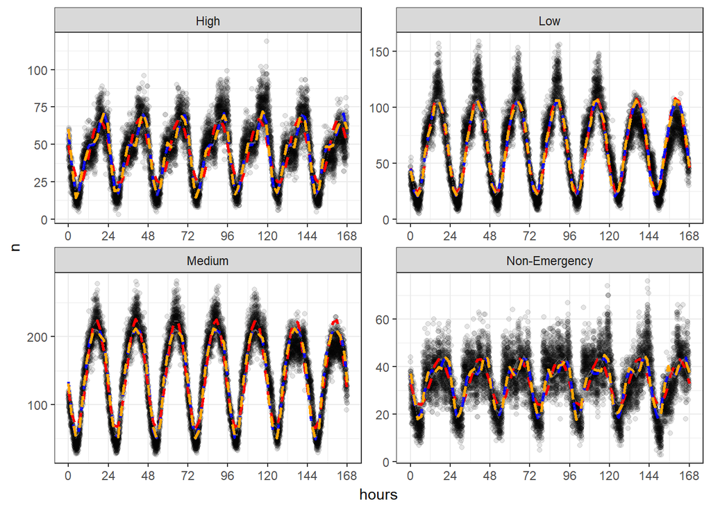

```r
#facet

ggplot(count(crime, t, priority) %>%
         filter(priority %in% c("High", "Low", "Medium",
                                "Non-Emergency") )) +
  aes(t, n) +
  geom_point(alpha = .1) +
  theme_bw() +
  geom_smooth(formula = y ~ sin(2*pi*x/period) + cos(2*pi*x/period), color = "red",
              method = "lm", linetype = 2, alpha = .5) +
  geom_smooth(formula = y ~ sin(2*pi*x/period) + cos(2*pi*x/period) +
                sin(4*pi*x/period) + cos(4*pi*x/period), color = "blue",
              method = "lm", linetype = 2, alpha = .5) +
  geom_smooth(formula = y ~ sin(2*pi*x/period) + cos(2*pi*x/period) +
                sin(4*pi*x/period) + cos(4*pi*x/period) +
                sin(8*pi*x/period) + cos(8*pi*x/period) +
                sin(16*pi*x/period) + cos(16*pi*x/period), color = "orange",
              method = "lm", linetype = 2, alpha = .5) +
  scale_x_continuous(breaks = seq(0, period * 7, period)) +
  labs(x = "hours", n = "number of reports") +
  facet_wrap(~ priority, scales = "free") +
  labs(x = "hours", n = "number of reports")
```

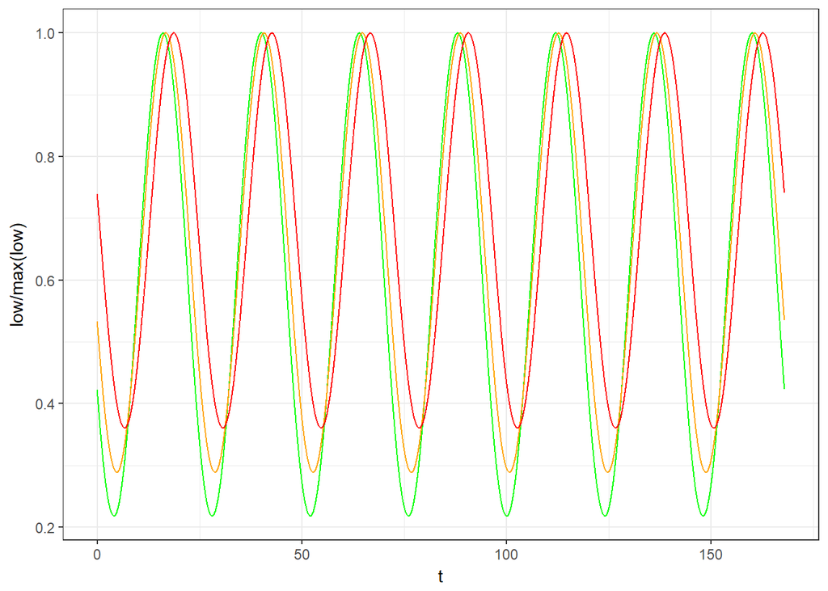

```r
model_high <- lm(n ~ sin(2*pi*t/period) + cos(2*pi*t/period), count(crime, t, priority),
                 subset = priority == "High")
model_med <- lm(n ~ sin(2*pi*t/period) + cos(2*pi*t/period), count(crime, t, priority),
                subset = priority == "Medium")
model_low <- lm(n ~ sin(2*pi*t/period) + cos(2*pi*t/period), count(crime, t, priority),
                subset = priority == "Low")


comp <- data.frame(count(crime, t, priority) %>% filter(priority == "High"),
                   low = model_low$fitted.values,
                   med = model_med$fitted.values,
                   high = model_high$fitted.values)

ggplot(comp) +
  geom_line(aes(t, low/max(low)), color = "green") +
  geom_line(aes(t, med/max(med)), color = "orange") +
  geom_line(aes(t, high/max(high)), color = "red") +
  theme_bw()
```